## Projet 11 Etude de marché pour la poule qui chante

# OBJECTIFS DE CE NOTEBOOK

#### - Nettoyer et préparer les différents jeux de données

#### - Réaliser les jointures entre les fichiers

#### - Constituer un dataset unifié contenant les variables essentielles pour l'étude de marché

# Sommaire

- Étape 1 - Importation des librairies et chargement des fichiers
  - 1.1 - Importation des librairies
  - 1.2 - Chargement des fichiers
- Etape 2 - Analyse exploratoire des fichiers
  - 2.1 - Analyse exploratoire du fichier stabilite_politique
  - 2.2 - Analyse exploratoire du fichier dispo_alimentaire
  - 2.3 - Analyse exploratoire du fichier PIB_habitant
  - 2.4 - Analyse exploratoire du fichier population
  - 2.5 - performance_logistique
  - 2.6 - Taux_droit_douane
- Étape 3 - Jointure des fichiers
  - 3.1 - Jointure
  - 3.2 - Finalisation du fichier final
  - 3.3 - Export du fichier final

# Étape 1 - Importation des librairies et chargement des fichiers

## 1.1 - Importation des librairies

```python
#Importation des librairies
import pandas as pd
import numpy as np
import matplotlib.pyplot as plt
```

```python
!pip install xlrd
```

```python
#Importation de la librairie plotly express
!pip install plotly
import plotly.express as px
```

## 1.2 - Chargement des fichiers

```python
#Importation du fichier Dispo_alimentaire_2017
dispo_alimentaire = pd.read_csv("Dispo_alimentaire_2017.csv")
#Importation du fichier Population_2000_2018
population_2000_2018 = pd.read_csv("Population_2000_2018.csv")
#Importation du fichier PIB_habitant
PIB_habitant = pd.read_csv("PIB_habitant.csv", skiprows=4)
#Importation du fichier stabilite_politique
stabilite_politique = pd.read_csv("stabilite_politique.csv", skiprows=4)
#Importation du fichier performance_logistique
performance_logistique = pd.read_csv("performance_logistique.csv", skiprows=4)
#Importation du fichier Taux_droit_douane
Taux_droit_douane = pd.read_excel("Taux_droit_douane.xls", skiprows=3)
```

# Étape 2 - Analyse exploratoire des fichiers

## 2.1 - Analyse exploratoire du fichier stabilite_politique

```python
# Traitement du fichier stabilite_politique
# Restructuration du format
stabilite_politique = stabilite_politique.melt(
    id_vars=['Country Name', 'Country Code'],
    var_name='annee',
    value_name='stabilite'
)
# Renommage et nettoyage
stabilite_politique.rename(columns={'Country Name': 'pays'}, inplace=True)

# Convertir les années en numérique
stabilite_politique['annee'] = pd.to_numeric(stabilite_politique['annee'], errors='coerce')

# Convertir la stabilité politique en nombre (et ignorer les valeurs texte)
stabilite_politique['stabilite'] = pd.to_numeric(stabilite_politique['stabilite'], errors='coerce')

# Supprimer les lignes où la valeur est manquante
stabilite_politique = stabilite_politique.dropna(subset=['stabilite'])

# Convertir en entier
stabilite_politique['stabilite'] = stabilite_politique['stabilite'].round(0).astype(int)

# Affichage des 5 premières lignes
stabilite_politique
```

|  | pays | Country Code | annee | stabilite |
| --- | --- | --- | --- | --- |
| 10110 | Afghanistan | AFG | 1996.0 | -2 |
| 10112 | Angola | AGO | 1996.0 | -2 |
| 10113 | Albanie | ALB | 1996.0 | 0 |
| 10114 | Andorre | AND | 1996.0 | 1 |
| 10116 | Émirats arabes unis | ARE | 1996.0 | 1 |
| ... | ... | ... | ... | ... |
| 17551 | Kosovo | XKX | 2023.0 | 0 |
| 17552 | Yémen, Rép. du | YEM | 2023.0 | -3 |
| 17553 | Afrique du Sud | ZAF | 2023.0 | -1 |
| 17554 | Zambie | ZMB | 2023.0 | 0 |
| 17555 | Zimbabwe | ZWE | 2023.0 | -1 |

5025 rows × 4 columns

```python
# Changement du type de la colonne stabilite
stabilite_politique['stabilite'] = stabilite_politique['stabilite'].round(0).astype(int)

#Changement du type de la colonne annee
stabilite_politique['annee'] = stabilite_politique['annee'].astype(int)
stabilite_politique.head()
```

|  | pays | Country Code | annee | stabilite |
| --- | --- | --- | --- | --- |
| 10110 | Afghanistan | AFG | 1996 | -2 |
| 10112 | Angola | AGO | 1996 | -2 |
| 10113 | Albanie | ALB | 1996 | 0 |
| 10114 | Andorre | AND | 1996 | 1 |
| 10116 | Émirats arabes unis | ARE | 1996 | 1 |

```python
# Garder uniquement l'année 2022
stabilite_politique = stabilite_politique[
    (stabilite_politique['annee'] == 2022)
]
```

```python
#Afficher les dimensions du dataset
print("Le tableau comporte {} observation(s) ou article(s)".format(stabilite_politique.shape[0]))
print("Le tableau comporte {} colonne(s)".format(stabilite_politique.shape[1]))
```

```
Le tableau comporte 205 observation(s) ou article(s)
Le tableau comporte 4 colonne(s)
```

```python
#Vérifiaction des valeurs manquantes
stabilite_politique.isna().any()
```

```
pays            False
Country Code    False
annee           False
stabilite       False
dtype: bool
```

Il n'y a pas de valeurs manquantes dans stabilite_politique

```python
#Vérification des doublons sur toutes les colonnes
stabilite_politique_doublon = stabilite_politique[stabilite_politique.duplicated()]

# Afficher les doublons (si existants)
print("Nombre de doublons :", len(stabilite_politique_doublon))
```

```
Nombre de doublons : 0
```

Il n'y a pas de doublons dans stabilite_politique

```python
#Suppression de la colonne Country Code
stabilite_politique = stabilite_politique.drop(columns=["Country Code"])
```

```python
#Suppression de l'annee
stabilite_politique.drop(columns=["annee"], inplace=True)
```

```python
#Affichage de la table
stabilite_politique
```

|  | pays | stabilite |
| --- | --- | --- |
| 17024 | Aruba | 1 |
| 17026 | Afghanistan | -3 |
| 17028 | Angola | -1 |
| 17029 | Albanie | 0 |
| 17030 | Andorre | 2 |
| ... | ... | ... |
| 17285 | Kosovo | 0 |
| 17286 | Yémen, Rép. du | -2 |
| 17287 | Afrique du Sud | -1 |
| 17288 | Zambie | 0 |
| 17289 | Zimbabwe | -1 |

205 rows × 2 columns

## Les outliers

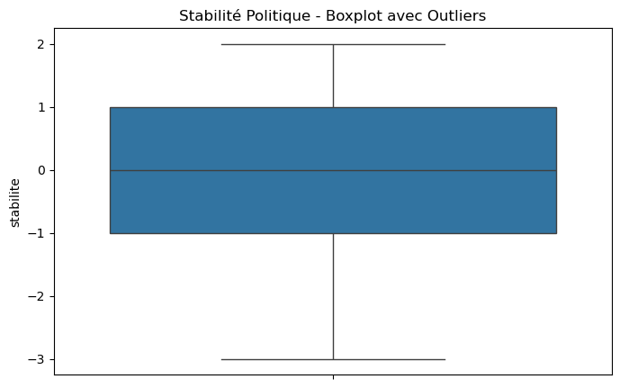

```
Outliers détectés : 0
Series([], Name: stabilite, dtype: int32)
```

```python
import matplotlib.pyplot as plt
import seaborn as sns

# Boxplot simple avec outliers
plt.figure(figsize=(8, 5))
sns.boxplot(y=stabilite_politique['stabilite'])
plt.title('Stabilité Politique - Boxplot avec Outliers')
plt.show()

# Compter les outliers
Q1 = stabilite_politique['stabilite'].quantile(0.25)
Q3 = stabilite_politique['stabilite'].quantile(0.75)
IQR = Q3 - Q1
outliers = stabilite_politique[(stabilite_politique['stabilite'] < Q1 - 1.5*IQR) |
                              (stabilite_politique['stabilite'] > Q3 + 1.5*IQR)]

print(f"Outliers détectés : {len(outliers)}")
print(outliers['stabilite'])
```

## 2.2 - Analyse exploratoire du fichier dispo_alimentaire

```python
#Affichage de la table
dispo_alimentaire
```

|  | Code Domaine | Domaine | Code zone | Zone | Code Élément | Élément | Code Produit | Produit | Code année | Année | Unité | Valeur | Symbole | Description du Symbole |
| --- | --- | --- | --- | --- | --- | --- | --- | --- | --- | --- | --- | --- | --- | --- |
| 0 | FBS | Nouveaux Bilans Alimentaire | 2 | Afghanistan | 5511 | Production | 2511 | Blé et produits | 2017 | 2017 | Milliers de tonnes | 4281.00 | S | Données standardisées |
| 1 | FBS | Nouveaux Bilans Alimentaire | 2 | Afghanistan | 5611 | Importations - Quantité | 2511 | Blé et produits | 2017 | 2017 | Milliers de tonnes | 2302.00 | S | Données standardisées |
| 2 | FBS | Nouveaux Bilans Alimentaire | 2 | Afghanistan | 5072 | Variation de stock | 2511 | Blé et produits | 2017 | 2017 | Milliers de tonnes | -119.00 | S | Données standardisées |
| 3 | FBS | Nouveaux Bilans Alimentaire | 2 | Afghanistan | 5911 | Exportations - Quantité | 2511 | Blé et produits | 2017 | 2017 | Milliers de tonnes | 0.00 | S | Données standardisées |
| 4 | FBS | Nouveaux Bilans Alimentaire | 2 | Afghanistan | 5301 | Disponibilité intérieure | 2511 | Blé et produits | 2017 | 2017 | Milliers de tonnes | 6701.00 | S | Données standardisées |
| ... | ... | ... | ... | ... | ... | ... | ... | ... | ... | ... | ... | ... | ... | ... |
| 176595 | FBS | Nouveaux Bilans Alimentaire | 181 | Zimbabwe | 5142 | Nourriture | 2899 | Miscellanees | 2017 | 2017 | Milliers de tonnes | 19.00 | S | Données standardisées |
| 176596 | FBS | Nouveaux Bilans Alimentaire | 181 | Zimbabwe | 645 | Disponibilité alimentaire en quantité (kg/pers... | 2899 | Miscellanees | 2017 | 2017 | kg | 1.33 | Fc | Donnée calculée |
| 176597 | FBS | Nouveaux Bilans Alimentaire | 181 | Zimbabwe | 664 | Disponibilité alimentaire (Kcal/personne/jour) | 2899 | Miscellanees | 2017 | 2017 | Kcal/personne/jour | 1.00 | Fc | Donnée calculée |
| 176598 | FBS | Nouveaux Bilans Alimentaire | 181 | Zimbabwe | 674 | Disponibilité de protéines en quantité (g/pers... | 2899 | Miscellanees | 2017 | 2017 | g/personne/jour | 0.04 | Fc | Donnée calculée |
| 176599 | FBS | Nouveaux Bilans Alimentaire | 181 | Zimbabwe | 684 | Disponibilité de matière grasse en quantité (g... | 2899 | Miscellanees | 2017 | 2017 | g/personne/jour | 0.02 | Fc | Donnée calculée |

176600 rows × 14 columns

```python
#Affichage des elements contenu dans la colonne Elements de dispo_alimentaire
dispo_alimentaire['Élément'].unique()
```

```
array(['Production', 'Importations - Quantité', 'Variation de stock',
       'Exportations - Quantité', 'Disponibilité intérieure',
       'Aliments pour animaux', 'Semences', 'Pertes', 'Résidus',
       'Nourriture',
       'Disponibilité alimentaire en quantité (kg/personne/an)',
       'Disponibilité alimentaire (Kcal/personne/jour)',
       'Disponibilité de protéines en quantité (g/personne/jour)',
       'Disponibilité de matière grasse en quantité (g/personne/jour)',
       'Traitement', 'Autres utilisations (non alimentaire)',
       'Alimentation pour touristes'], dtype=object)
```

```python
#Affichage des elements contenu dans la colonne Produit de dispo_alimentaire
dispo_alimentaire['Produit'].unique()
```

```
array(['Blé et produits', 'Riz et produits', 'Orge et produits',
       'Maïs et produits', 'Seigle et produits', 'Avoine',
       'Millet et produits', 'Sorgho et produits', 'Céréales, Autres',
       'Pommes de Terre et produits', 'Ignames', 'Racines nda',
       'Sucre, canne', 'Sucre, betterave', 'Sucre Eq Brut',
       'Edulcorants Autres', 'Miel', 'Haricots', 'Pois',
       'Légumineuses Autres et produits', 'Noix et produits', 'Soja',
       'Arachides Decortiquees', 'Graines de tournesol',
       'Graines Colza/Moutarde', 'Graines de coton', 'Coco (Incl Coprah)',
       'Sésame', 'Olives', 'Plantes Oleiferes, Autre', 'Huile de Soja',
       "Huile d'Arachide", 'Huile de Tournesol',
       'Huile de Colza&Moutarde', 'Huile Graines de Coton',
       'Huile de Palmistes', 'Huile de Palme', 'Huile de Coco',
       'Huile de Sésame', "Huile d'Olive", 'Huile de Son de Riz',
       'Huile de Germe de Maïs', 'Huil Plantes Oleif Autr',
       'Tomates et produits', 'Oignons', 'Légumes, Autres',
       'Oranges, Mandarines', 'Citrons & Limes et produits',
       'Pamplemousse et produits', 'Agrumes, Autres', 'Bananes',
       'Pommes et produits', 'Ananas et produits', 'Dattes', 'Raisin',
       'Fruits, Autres', 'Café et produits', 'Feve de Cacao et produits',
       'Thé', 'Poivre', 'Piments', 'Girofles', 'Épices, Autres', 'Vin',
       'Bière', 'Boissons Fermentés', 'Boissons Alcooliques',
       'Alcool, non Comestible', 'Viande de Bovins',
       "Viande d'Ovins/Caprins", 'Viande de Suides',
       'Viande de Volailles', 'Viande, Autre', 'Abats Comestible',
       'Beurre, Ghee', 'Crème', 'Graisses Animales Crue', 'Oeufs',
       'Lait - Excl Beurre', 'Poissons Eau Douce',
       'Aliments pour enfants', 'Miscellanees', 'Manioc et produits',
       'Patates douces', 'Palmistes', 'Bananes plantains',
       'Huiles de Poissons', 'Huiles de Foie de Poisso', 'Perciform',
       'Poissons Pelagiques', 'Poissons Marins, Autres', 'Crustacés',
       'Cephalopodes', 'Mollusques, Autres', 'Animaux Aquatiques Autre',
       'Plantes Aquatiques', 'Sucre non centrifugé',
       'Viande de Anim Aquatiq'], dtype=object)
```

```python
# Supprimer les doublons de colonnes inutiles
dispo_alimentaire = dispo_alimentaire.drop(columns=[
    "Code Domaine",
    "Code zone",
    "Code Élément",
    "Code Produit",
    "Code année",
    "Symbole",
    "Description du Symbole"
])
```

```python
# Renommer les colonnes
dispo_alimentaire = dispo_alimentaire.rename(columns={
    "Domaine": "domaine",
    "Zone": "pays",
    "Élément": "element",
    "Produit": "produit",
    "Année": "annee",
    "Unité": "unite",
    "Valeur": "valeur"
})

dispo_alimentaire.head()
```

|  | domaine | pays | element | produit | annee | unite | valeur |
| --- | --- | --- | --- | --- | --- | --- | --- |
| 0 | Nouveaux Bilans Alimentaire | Afghanistan | Production | Blé et produits | 2017 | Milliers de tonnes | 4281.0 |
| 1 | Nouveaux Bilans Alimentaire | Afghanistan | Importations - Quantité | Blé et produits | 2017 | Milliers de tonnes | 2302.0 |
| 2 | Nouveaux Bilans Alimentaire | Afghanistan | Variation de stock | Blé et produits | 2017 | Milliers de tonnes | -119.0 |
| 3 | Nouveaux Bilans Alimentaire | Afghanistan | Exportations - Quantité | Blé et produits | 2017 | Milliers de tonnes | 0.0 |
| 4 | Nouveaux Bilans Alimentaire | Afghanistan | Disponibilité intérieure | Blé et produits | 2017 | Milliers de tonnes | 6701.0 |

```python
#Selection de la viande de volailles
dispo_alimentaire = dispo_alimentaire[dispo_alimentaire["produit"] == "Viande de Volailles"]
dispo_alimentaire.head()
```

|  | domaine | pays | element | produit | annee | unite | valeur |
| --- | --- | --- | --- | --- | --- | --- | --- |
| 651 | Nouveaux Bilans Alimentaire | Afghanistan | Production | Viande de Volailles | 2017 | Milliers de tonnes | 28.0 |
| 652 | Nouveaux Bilans Alimentaire | Afghanistan | Importations - Quantité | Viande de Volailles | 2017 | Milliers de tonnes | 29.0 |
| 653 | Nouveaux Bilans Alimentaire | Afghanistan | Variation de stock | Viande de Volailles | 2017 | Milliers de tonnes | 0.0 |
| 654 | Nouveaux Bilans Alimentaire | Afghanistan | Disponibilité intérieure | Viande de Volailles | 2017 | Milliers de tonnes | 57.0 |
| 655 | Nouveaux Bilans Alimentaire | Afghanistan | Pertes | Viande de Volailles | 2017 | Milliers de tonnes | 2.0 |

```python
# Changement du type des colonnes
dispo_alimentaire["annee"] = pd.to_numeric(dispo_alimentaire["annee"], errors="coerce").astype("Int64")
dispo_alimentaire["valeur"] = pd.to_numeric(dispo_alimentaire["valeur"], errors="coerce")
dispo_alimentaire.head()
```

|  | domaine | pays | element | produit | annee | unite | valeur |
| --- | --- | --- | --- | --- | --- | --- | --- |
| 651 | Nouveaux Bilans Alimentaire | Afghanistan | Production | Viande de Volailles | 2017 | Milliers de tonnes | 28.0 |
| 652 | Nouveaux Bilans Alimentaire | Afghanistan | Importations - Quantité | Viande de Volailles | 2017 | Milliers de tonnes | 29.0 |
| 653 | Nouveaux Bilans Alimentaire | Afghanistan | Variation de stock | Viande de Volailles | 2017 | Milliers de tonnes | 0.0 |
| 654 | Nouveaux Bilans Alimentaire | Afghanistan | Disponibilité intérieure | Viande de Volailles | 2017 | Milliers de tonnes | 57.0 |
| 655 | Nouveaux Bilans Alimentaire | Afghanistan | Pertes | Viande de Volailles | 2017 | Milliers de tonnes | 2.0 |

```python
# Pivot de la table pour créer des nouvelles colonnes
dispo_alimentaire = dispo_alimentaire.pivot_table(
    index=["pays", "produit", "annee"],
    columns="element",
    values="valeur",
    aggfunc="sum"
).reset_index()

# Renommer les colonnes d'intérêt
dispo_alimentaire = dispo_alimentaire.rename(columns={
    "Production": "production",
    "Importations - Quantité": "importation_qte",
    "Disponibilité intérieure": "disponibilite_interieure_qte"
})

# Garder uniquement les colonnes utiles
dispo_alimentaire = dispo_alimentaire[[
    "pays", "produit", "annee",
    "production", "importation_qte", "disponibilite_interieure_qte"
]]

# Vérifier le résultat
dispo_alimentaire.head()
```

| element | pays | produit | annee | production | importation_qte | disponibilite_interieure_qte |
| --- | --- | --- | --- | --- | --- | --- |
| 0 | Afghanistan | Viande de Volailles | 2017 | 28.0 | 29.0 | 57.0 |
| 1 | Afrique du Sud | Viande de Volailles | 2017 | 1667.0 | 514.0 | 2118.0 |
| 2 | Albanie | Viande de Volailles | 2017 | 13.0 | 38.0 | 47.0 |
| 3 | Algérie | Viande de Volailles | 2017 | 275.0 | 2.0 | 277.0 |
| 4 | Allemagne | Viande de Volailles | 2017 | 1514.0 | 842.0 | 1739.0 |

```python
#Affichage des pays contenus dans la colonne pays
dispo_alimentaire['pays'].unique()
```

```
array(['Afghanistan', 'Afrique du Sud', 'Albanie', 'Algérie', 'Allemagne',
       'Angola', 'Antigua-et-Barbuda', 'Arabie saoudite', 'Argentine',
       'Arménie', 'Australie', 'Autriche', 'Azerbaïdjan', 'Bahamas',
       'Bangladesh', 'Barbade', 'Belgique', 'Belize',
       'Bolivie (État plurinational de)', 'Bosnie-Herzégovine',
       'Botswana', 'Brésil', 'Bulgarie', 'Burkina Faso', 'Bélarus',
       'Bénin', 'Cabo Verde', 'Cambodge', 'Cameroun', 'Canada', 'Chili',
       'Chine - RAS de Hong-Kong', 'Chine - RAS de Macao',
       'Chine, Taiwan Province de', 'Chine, continentale', 'Chypre',
       'Colombie', 'Congo', 'Costa Rica', 'Croatie', 'Cuba',
       "Côte d'Ivoire", 'Danemark', 'Djibouti', 'Dominique',
       'El Salvador', 'Espagne', 'Estonie', 'Eswatini', 'Fidji',
       'Finlande', 'France', 'Fédération de Russie', 'Gabon', 'Gambie',
       'Ghana', 'Grenade', 'Grèce', 'Guatemala', 'Guinée',
       'Guinée-Bissau', 'Guyana', 'Géorgie', 'Haïti', 'Honduras',
       'Hongrie', 'Inde', 'Indonésie', "Iran (République islamique d')",
       'Iraq', 'Irlande', 'Islande', 'Israël', 'Italie', 'Jamaïque',
       'Japon', 'Jordanie', 'Kazakhstan', 'Kenya', 'Kirghizistan',
       'Kiribati', 'Koweït', 'Lesotho', 'Lettonie', 'Liban', 'Libéria',
       'Lituanie', 'Luxembourg', 'Macédoine du Nord', 'Madagascar',
       'Malaisie', 'Malawi', 'Maldives', 'Mali', 'Malte', 'Maroc',
       'Maurice', 'Mauritanie', 'Mexique', 'Mongolie', 'Monténégro',
       'Mozambique', 'Myanmar', 'Namibie', 'Nicaragua', 'Niger',
       'Nigéria', 'Norvège', 'Nouvelle-Calédonie', 'Nouvelle-Zélande',
       'Népal', 'Oman', 'Ouganda', 'Ouzbékistan', 'Pakistan', 'Panama',
       'Paraguay', 'Pays-Bas', 'Philippines', 'Pologne',
       'Polynésie française', 'Portugal', 'Pérou', 'Roumanie',
       "Royaume-Uni de Grande-Bretagne et d'Irlande du Nord", 'Rwanda',
       'République centrafricaine', 'République de Corée',
       'République de Moldova', 'République dominicaine',
       'République démocratique populaire lao',
       'République populaire démocratique de Corée',
       'République-Unie de Tanzanie', 'Saint-Kitts-et-Nevis',
       'Saint-Vincent-et-les Grenadines', 'Sainte-Lucie', 'Samoa',
       'Sao Tomé-et-Principe', 'Serbie', 'Sierra Leone', 'Slovaquie',
       'Slovénie', 'Soudan', 'Sri Lanka', 'Suisse', 'Suriname', 'Suède',
       'Sénégal', 'Tadjikistan', 'Tchad', 'Tchéquie', 'Thaïlande',
       'Timor-Leste', 'Togo', 'Trinité-et-Tobago', 'Tunisie',
       'Turkménistan', 'Turquie', 'Ukraine', 'Uruguay', 'Vanuatu',
       'Venezuela (République bolivarienne du)', 'Viet Nam', 'Yémen',
       'Zambie', 'Zimbabwe', 'Égypte', 'Émirats arabes unis', 'Équateur',
       "États-Unis d'Amérique", 'Éthiopie', 'Îles Salomon'], dtype=object)
```

```python
#Renommer les pays
# Dictionnaire de renommage
renommage_pays = {
    "République populaire démocratique de Corée": "Corée du Nord",
    "Chine - RAS de Hong-Kong": "Taiwan province de Chine",
    "Iran (République islamique d')": "Iran",
    "Venezuela (République bolivarienne du)": "Venezuela"
}

# Application du renommage
dispo_alimentaire["pays"] = dispo_alimentaire["pays"].replace(renommage_pays)
```

```python
#Vérification de valeurs manquantes
dispo_alimentaire.isna().any()
```

```
element
pays                            False
produit                         False
annee                           False
production                       True
importation_qte                  True
disponibilite_interieure_qte     True
dtype: bool
```

Il y a des valeurs manquantes dans les colonnes production, importation_qte, disponibilite_interieure_qte nous allons donc les supprimer

```python
#Suppression des lignes avec des valeurs manquantes
dispo_alimentaire = dispo_alimentaire.dropna()
dispo_alimentaire
```

| element | pays | produit | annee | production | importation_qte | disponibilite_interieure_qte |
| --- | --- | --- | --- | --- | --- | --- |
| 0 | Afghanistan | Viande de Volailles | 2017 | 28.0 | 29.0 | 57.0 |
| 1 | Afrique du Sud | Viande de Volailles | 2017 | 1667.0 | 514.0 | 2118.0 |
| 2 | Albanie | Viande de Volailles | 2017 | 13.0 | 38.0 | 47.0 |
| 3 | Algérie | Viande de Volailles | 2017 | 275.0 | 2.0 | 277.0 |
| 4 | Allemagne | Viande de Volailles | 2017 | 1514.0 | 842.0 | 1739.0 |
| ... | ... | ... | ... | ... | ... | ... |
| 167 | Émirats arabes unis | Viande de Volailles | 2017 | 48.0 | 433.0 | 412.0 |
| 168 | Équateur | Viande de Volailles | 2017 | 340.0 | 0.0 | 341.0 |
| 169 | États-Unis d'Amérique | Viande de Volailles | 2017 | 21914.0 | 123.0 | 18266.0 |
| 170 | Éthiopie | Viande de Volailles | 2017 | 14.0 | 1.0 | 14.0 |
| 171 | Îles Salomon | Viande de Volailles | 2017 | 0.0 | 6.0 | 3.0 |

168 rows × 6 columns

## Les outliers

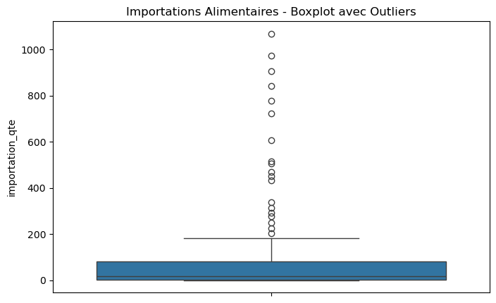

```
Outliers détectés : 19
element                                               pays  importation_qte
1                                           Afrique du Sud            514.0
4                                                Allemagne            842.0
5                                                   Angola            277.0
7                                          Arabie saoudite            722.0
16                                                Belgique            338.0
31                                Taiwan province de Chine            907.0
34                                     Chine, continentale            452.0
40                                                    Cuba            312.0
46                                                 Espagne            205.0
51                                                  France            506.0
52                                    Fédération de Russie            226.0
69                                                    Iraq            470.0
75                                                   Japon           1069.0
98                                                 Mexique            972.0
117                                               Pays-Bas            608.0
118                                            Philippines            249.0
124      Royaume-Uni de Grande-Bretagne et d'Irlande du...            779.0
162                                               Viet Nam            291.0
167                                    Émirats arabes unis            433.0
```

```python
# Boxplot simple avec outliers
plt.figure(figsize=(8, 5))
sns.boxplot(y=dispo_alimentaire['importation_qte'])
plt.title('Importations Alimentaires - Boxplot avec Outliers')
plt.show()

# Compter les outliers
Q1 = dispo_alimentaire['importation_qte'].quantile(0.25)
Q3 = dispo_alimentaire['importation_qte'].quantile(0.75)
IQR = Q3 - Q1
outliers = dispo_alimentaire[(dispo_alimentaire['importation_qte'] < Q1 - 1.5*IQR) |
                             (dispo_alimentaire['importation_qte'] > Q3 + 1.5*IQR)]

print(f"Outliers détectés : {len(outliers)}")
print(outliers[['pays', 'importation_qte']])
```

## Les valeurs aberrantes observées s’expliquent par des volumes d’importation de viande de volaille nettement plus élevés que ceux des autres pays, ce qui reflète une forte demande pour ce produit.

## 2.3 - Analyse exploratoire du fichier PIB_habitant

```python
# Mise à jour du format (chaque ligne = un pays + une année)
PIB_habitant = PIB_habitant.melt(
    id_vars=['Country Name', 'Country Code'],
    var_name='annee',
    value_name='pib_hab'
)

# Renommage et nettoyage
PIB_habitant.rename(columns={'Country Name': 'pays'}, inplace=True)
PIB_habitant['annee'] = pd.to_numeric(PIB_habitant['annee'], errors='coerce')
PIB_habitant = PIB_habitant.dropna(subset=['pib_hab'])
```

```python
# Filtrer sur 2022
PIB_habitant = PIB_habitant[(PIB_habitant['annee'] == 2022)]
PIB_habitant.head()
```

|  | pays | Country Code | annee | pib_hab |
| --- | --- | --- | --- | --- |
| 17024 | Aruba | ABW | 2022.0 | 41649.450792 |
| 17025 | NaN | AFE | 2022.0 | 4229.086486 |
| 17026 | Afghanistan | AFG | 2022.0 | 2122.995815 |
| 17027 | NaN | AFW | 2022.0 | 5169.145547 |
| 17028 | Angola | AGO | 2022.0 | 7924.888806 |

```python
# Suppression de la colonne Country Code
PIB_habitant= PIB_habitant.drop(columns=['Country Code'])

# Changement de la colonne 'annee' en entier
PIB_habitant['annee'] = PIB_habitant['annee'].astype(int)
PIB_habitant['pib_hab'] = PIB_habitant['pib_hab'].astype(int)

# Affichage du résultat
PIB_habitant.head()
```

|  | pays | annee | pib_hab |
| --- | --- | --- | --- |
| 17024 | Aruba | 2022 | 41649 |
| 17025 | NaN | 2022 | 4229 |
| 17026 | Afghanistan | 2022 | 2122 |
| 17027 | NaN | 2022 | 5169 |
| 17028 | Angola | 2022 | 7924 |

```python
#Afficher les dimensions du dataset
print("Le tableau comporte {} observation(s) ou article(s)".format(PIB_habitant.shape[0]))
print("Le tableau comporte {} colonne(s)".format(PIB_habitant.shape[1]))
```

```
Le tableau comporte 247 observation(s) ou article(s)
Le tableau comporte 3 colonne(s)
```

```python
#Vérification des doublons sur toutes les colonnes
PIB_habitant_doublons = PIB_habitant[PIB_habitant.duplicated()]

# Afficher les doublons (si existants)
print("Nombre de doublons :", len(PIB_habitant_doublons))
```

```
Nombre de doublons : 0
```

Il n'y a pas de doublons dans PIB_habitant

```python
#Vérifiaction des valeurs manquantes
PIB_habitant.isna().any()
```

```
pays        True
annee      False
pib_hab    False
dtype: bool
```

Il y a des valeurs manquantes dans PIB_habitant dans la colonne pays donc on va les supprimer

```python
#Suppression des valeurs manquantes de la colonne pays
PIB_habitant = PIB_habitant.dropna(subset=["pays"])
```

```python
#Suppression de la colonne annee
PIB_habitant.drop(columns=["annee"], inplace=True)
```

```python
#Affichage de la table
PIB_habitant.head()
```

|  | pays | pib_hab |
| --- | --- | --- |
| 17024 | Aruba | 41649 |
| 17026 | Afghanistan | 2122 |
| 17028 | Angola | 7924 |
| 17029 | Albanie | 19446 |
| 17030 | Andorre | 68470 |

## Les outliers

[figure not shown]

```
Outliers détectés : 6
           pays  pib_hab
24     Bermudes   105142
101     Irlande   136104
133  Luxembourg   143381
162     Norvège   123150
183       Qatar   122920
191   Singapour   143094
```

```python
# Boxplot avec outliers
plt.figure(figsize=(8, 5))
sns.boxplot(y=PIB_habitant['pib_hab'])
plt.title('Importations Alimentaires - Boxplot avec Outliers')
plt.show()

# Compter les outliers
dispo_reset = PIB_habitant.reset_index(drop=True)

Q1 = dispo_reset['pib_hab'].quantile(0.25)
Q3 = dispo_reset['pib_hab'].quantile(0.75)
IQR = Q3 - Q1
outliers = dispo_reset[(dispo_reset['pib_hab'] < Q1 - 1.5*IQR) |
                       (dispo_reset['pib_hab'] > Q3 + 1.5*IQR)]

print(f"Outliers détectés : {len(outliers)}")
print(outliers[['pays', 'pib_hab']])
```

## Ces outliers correspondent à des pays à très haut revenu par habitant. Leur PIB/habitant très élevé reflète des économies développées ou à forte spécialisation financière et énergétique.

## 2.4 - Analyse exploratoire du fichier population

```python
#Affichage de la table population
population_2000_2018.head()
```

|  | Code Domaine | Domaine | Code zone | Zone | Code Élément | Élément | Code Produit | Produit | Code année | Année | Unité | Valeur | Symbole | Description du Symbole | Note |
| --- | --- | --- | --- | --- | --- | --- | --- | --- | --- | --- | --- | --- | --- | --- | --- |
| 0 | OA | Séries temporelles annuelles | 2 | Afghanistan | 511 | Population totale | 3010 | Population-Estimations | 2000 | 2000 | 1000 personnes | 20779.953 | X | Sources internationales sûres | NaN |
| 1 | OA | Séries temporelles annuelles | 2 | Afghanistan | 511 | Population totale | 3010 | Population-Estimations | 2001 | 2001 | 1000 personnes | 21606.988 | X | Sources internationales sûres | NaN |
| 2 | OA | Séries temporelles annuelles | 2 | Afghanistan | 511 | Population totale | 3010 | Population-Estimations | 2002 | 2002 | 1000 personnes | 22600.770 | X | Sources internationales sûres | NaN |
| 3 | OA | Séries temporelles annuelles | 2 | Afghanistan | 511 | Population totale | 3010 | Population-Estimations | 2003 | 2003 | 1000 personnes | 23680.871 | X | Sources internationales sûres | NaN |
| 4 | OA | Séries temporelles annuelles | 2 | Afghanistan | 511 | Population totale | 3010 | Population-Estimations | 2004 | 2004 | 1000 personnes | 24726.684 | X | Sources internationales sûres | NaN |

```python
#Supprimer les colonnes inutiles
colonnes_a_supprimer = [
    'Code Domaine', 'Domaine', 'Code zone', 'Code Élément',
    'Code Produit', 'Code année', 'Symbole', 'Description du Symbole', 'Note']
population_2000_2018 = population_2000_2018.drop(columns=colonnes_a_supprimer, errors='ignore')
```

```python
#Renommer les colonnes pour plus de clarté
population_2000_2018 = population_2000_2018.rename(columns={
    'Zone': 'pays',
    'Élément': 'Type_donnée',
    'Année': 'annee',
    'Unité': 'Unite',
    'Valeur': 'Population'})
# Réinitialiser l’index
population_2000_2018 = population_2000_2018.reset_index(drop=True)
```

```python
# Valeurs manquantes
population_2000_2018.isna().any()
```

```
pays           False
Type_donnée    False
Produit        False
annee          False
Unite          False
Population     False
dtype: bool
```

Il n'y a pas de valeurs manquantes dans population_2000_2018

```python
# Verification des doublons
population_2000_2018_doublons = population_2000_2018[population_2000_2018.duplicated()]
# Afficher les doublons (si existants)
print("Nombre de doublons :", len(population_2000_2018_doublons))
```

```
Nombre de doublons : 0
```

```python
#Afficher les dimensions du dataset
print("Le tableau comporte {} observation(s) ou article(s)".format(population_2000_2018.shape[0]))
print("Le tableau comporte {} colonne(s)".format(population_2000_2018.shape[1]))
```

```
Le tableau comporte 4411 observation(s) ou article(s)
Le tableau comporte 6 colonne(s)
```

Il n'y a pas de doublons dans population_2000_2018

```python
# Changement du type des données
population_2000_2018['annee'] = population_2000_2018['annee'].astype(int)
population_2000_2018['Population'] = population_2000_2018['Population'].astype(int)
population_2000_2018.head()
```

|  | pays | Type_donnée | Produit | annee | Unite | Population |
| --- | --- | --- | --- | --- | --- | --- |
| 0 | Afghanistan | Population totale | Population-Estimations | 2000 | 1000 personnes | 20779 |
| 1 | Afghanistan | Population totale | Population-Estimations | 2001 | 1000 personnes | 21606 |
| 2 | Afghanistan | Population totale | Population-Estimations | 2002 | 1000 personnes | 22600 |
| 3 | Afghanistan | Population totale | Population-Estimations | 2003 | 1000 personnes | 23680 |
| 4 | Afghanistan | Population totale | Population-Estimations | 2004 | 1000 personnes | 24726 |

```python
population_2000_2018.loc[population_2000_2018['Unite'] == '1000 personnes', 'Population'] *= 1000
population_2000_2018['Unite'] = population_2000_2018['Unite'].replace('1000 personnes', 'personnes')
population_2000_2018.head()
```

|  | pays | Type_donnée | Produit | annee | Unite | Population |
| --- | --- | --- | --- | --- | --- | --- |
| 0 | Afghanistan | Population totale | Population-Estimations | 2000 | personnes | 20779000 |
| 1 | Afghanistan | Population totale | Population-Estimations | 2001 | personnes | 21606000 |
| 2 | Afghanistan | Population totale | Population-Estimations | 2002 | personnes | 22600000 |
| 3 | Afghanistan | Population totale | Population-Estimations | 2003 | personnes | 23680000 |
| 4 | Afghanistan | Population totale | Population-Estimations | 2004 | personnes | 24726000 |

```python
#Suppression des colonnes inutiles
population_2000_2018 = population_2000_2018.drop(columns=['Unite', 'Type_donnée', 'Produit'])
```

```python
# Filtrer sur 2018
population = population_2000_2018[(population_2000_2018['annee'] == 2018)]
population.head()
```

|  | pays | annee | Population |
| --- | --- | --- | --- |
| 18 | Afghanistan | 2018 | 37171000 |
| 37 | Afrique du Sud | 2018 | 57792000 |
| 56 | Albanie | 2018 | 2882000 |
| 75 | Algérie | 2018 | 42228000 |
| 94 | Allemagne | 2018 | 83124000 |

## Les outliers

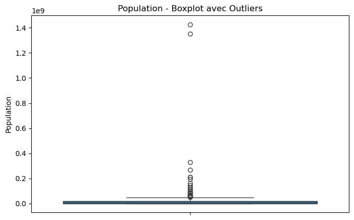

```
Outliers détectés : 29
                                                  pays  Population
1                                       Afrique du Sud    57792000
4                                            Allemagne    83124000
19                                          Bangladesh   161376000
31                                              Brésil   209469000
43                                 Chine, continentale  1427647000
46                                            Colombie    49661000
57                                              Égypte    98423000
65                               États-Unis d'Amérique   327096000
66                                            Éthiopie   109224000
67                                Fédération de Russie   145734000
70                                              France    64990000
103                                               Inde  1352642000
104                                          Indonésie   267670000
```

[output cut: 16 more lines]

```python
# Boxplot avec outliers
plt.figure(figsize=(8, 5))
sns.boxplot(y=population['Population'])
plt.title('Population - Boxplot avec Outliers')
plt.show()

# Compter les outliers
data_reset = population.reset_index(drop=True)

Q1 = data_reset['Population'].quantile(0.25)
Q3 = data_reset['Population'].quantile(0.75)
IQR = Q3 - Q1
outliers = data_reset[(data_reset['Population'] < Q1 - 1.5*IQR) |
                       (data_reset['Population'] > Q3 + 1.5*IQR)]

print(f"Outliers détectés : {len(outliers)}")
print(outliers[['pays', 'Population']])
```

## Ces outliers sont les pays les plus peuplés du monde. Leur population est tellement grande qu’ils se démarquent clairement des autres.

## 2.5 - performance_logistique

```python
performance_logistique.head()
```

|  | Country Name | Country Code | Indicator Name | Indicator Code | 1960 | 1961 | 1962 | 1963 | 1964 | 1965 | ... | 2016 | 2017 | 2018 | 2019 | 2020 | 2021 | 2022 | 2023 | 2024 | Unnamed: 69 |
| --- | --- | --- | --- | --- | --- | --- | --- | --- | --- | --- | --- | --- | --- | --- | --- | --- | --- | --- | --- | --- | --- |
| 0 | Aruba | ABW | Indice de performance logistique : performance... | LP.LPI.OVRL.XQ | NaN | NaN | NaN | NaN | NaN | NaN | ... | NaN | NaN | NaN | NaN | NaN | NaN | NaN | NaN | NaN | NaN |
| 1 | NaN | AFE | Indice de performance logistique : performance... | LP.LPI.OVRL.XQ | NaN | NaN | NaN | NaN | NaN | NaN | ... | 2.578623 | NaN | 2.492222 | NaN | NaN | NaN | 2.618182 | NaN | NaN | NaN |
| 2 | Afghanistan | AFG | Indice de performance logistique : performance... | LP.LPI.OVRL.XQ | NaN | NaN | NaN | NaN | NaN | NaN | ... | 2.141282 | NaN | 1.950000 | NaN | NaN | NaN | 1.900000 | NaN | NaN | NaN |
| 3 | NaN | AFW | Indice de performance logistique : performance... | LP.LPI.OVRL.XQ | NaN | NaN | NaN | NaN | NaN | NaN | ... | 2.349977 | NaN | 2.413333 | NaN | NaN | NaN | 2.473333 | NaN | NaN | NaN |
| 4 | Angola | AGO | Indice de performance logistique : performance... | LP.LPI.OVRL.XQ | NaN | NaN | NaN | NaN | NaN | NaN | ... | 2.241183 | NaN | 2.050000 | NaN | NaN | NaN | 2.100000 | NaN | NaN | NaN |

5 rows × 70 columns

```python
# Sélectionner les colonnes utiles
performance_logistique = performance_logistique.loc[:, ["Country Name", "Country Code"]
+ performance_logistique.columns[performance_logistique.columns.str.isdigit()].tolist()]

# Transformer le tableau large → long (avec une colonne "annee")
performance_logistique = performance_logistique.melt(
    id_vars=["Country Name", "Country Code"],
    var_name="annee",
    value_name="indice_performance_logistique"
)

# Changement du nom des colonnes
performance_logistique = performance_logistique.rename(columns={
    "Country Name": "pays",
    "Country Code": "code_pays"
})
```

```python
# Supprimer les lignes sans valeur (NaN)
performance_logistique = performance_logistique.dropna(subset=["indice_performance_logistique"])

# Convertir l’année en entier
performance_logistique["annee"] = performance_logistique["annee"].astype(int)

# Affichage du résultat
performance_logistique.head()
```

|  | pays | code_pays | annee | indice_performance_logistique |
| --- | --- | --- | --- | --- |
| 12503 | NaN | AFE | 2007 | 2.385238 |
| 12504 | Afghanistan | AFG | 2007 | 1.210000 |
| 12505 | NaN | AFW | 2007 | 2.303333 |
| 12506 | Angola | AGO | 2007 | 2.480000 |
| 12507 | Albanie | ALB | 2007 | 2.080000 |

```python
# Séparer les données de 2022 et des autres années
perf_2022 = performance_logistique[performance_logistique['annee'] == 2022].copy()
perf_autres = performance_logistique[performance_logistique['annee'] != 2023].copy()

# Trier les autres années pour chaque pays (priorité à l’année la plus récente)
perf_autres = perf_autres.sort_values(by=['pays', 'annee'], ascending=[True, False])

# Garder la donnée la plus proche par pays
perf_proche = perf_autres.drop_duplicates(subset='pays', keep='first')

# Remplir les NaN de 2022 avec les valeurs de l’année proche
performance_logistique = perf_2022.combine_first(perf_proche)

# Affichage
print("Données 2022 complétées dans performance_logistique :")
performance_logistique
```

```
Données 2022 complétées dans performance_logistique :
```

|  | pays | code_pays | annee | indice_performance_logistique |
| --- | --- | --- | --- | --- |
| 12739 | Timor-Leste | TLS | 2007 | 1.710000 |
| 14379 | Azerbaïdjan | AZE | 2014 | 2.448376 |
| 14968 | Éthiopie | ETH | 2016 | 2.376767 |
| 15061 | Mozambique | MOZ | 2016 | 2.684105 |
| 15142 | Tanzanie | TZA | 2016 | 2.990185 |
| ... | ... | ... | ... | ... |
| 16749 | Viet Nam | VNM | 2022 | 3.300000 |
| 16751 | Monde | WLD | 2022 | 3.000000 |
| 16754 | Yémen, Rép. du | YEM | 2022 | 2.200000 |
| 16755 | Afrique du Sud | ZAF | 2022 | 3.700000 |
| 16757 | Zimbabwe | ZWE | 2022 | 2.500000 |

217 rows × 4 columns

```python
performance_logistique.isna().any()
```

```
pays                              True
code_pays                        False
annee                            False
indice_performance_logistique    False
dtype: bool
```

Il y a des valeurs manquantes dans la colonne pays donc nous allons les supprimer

```python
#Suppression des valeurs manquantes dans la colonne pays
performance_logistique = performance_logistique.dropna(subset=["pays"])
performance_logistique
```

|  | pays | code_pays | annee | indice_performance_logistique |
| --- | --- | --- | --- | --- |
| 12739 | Timor-Leste | TLS | 2007 | 1.710000 |
| 14379 | Azerbaïdjan | AZE | 2014 | 2.448376 |
| 14968 | Éthiopie | ETH | 2016 | 2.376767 |
| 15061 | Mozambique | MOZ | 2016 | 2.684105 |
| 15142 | Tanzanie | TZA | 2016 | 2.990185 |
| ... | ... | ... | ... | ... |
| 16749 | Viet Nam | VNM | 2022 | 3.300000 |
| 16751 | Monde | WLD | 2022 | 3.000000 |
| 16754 | Yémen, Rép. du | YEM | 2022 | 2.200000 |
| 16755 | Afrique du Sud | ZAF | 2022 | 3.700000 |
| 16757 | Zimbabwe | ZWE | 2022 | 2.500000 |

215 rows × 4 columns

```python
#Affichage du nombre de doublons
performance_logistique.duplicated().sum()
```

```
0
```

Il n'y a pas de doublons dans performance_logistique

```python
#Suppression de la colonne code_pays
performance_logistique = performance_logistique.drop(columns=["code_pays"])
```

```python
#Afficher les dimensions du dataset
print("Le tableau comporte {} observation(s) ou article(s)".format(performance_logistique.shape[0]))
print("Le tableau comporte {} colonne(s)".format(performance_logistique.shape[1]))
```

```
Le tableau comporte 215 observation(s) ou article(s)
Le tableau comporte 3 colonne(s)
```

```python
#Suppression de la colonne annee
performance_logistique.drop(columns=["annee"], inplace=True)
```

```python
#Affichage du dataset
performance_logistique
```

|  | pays | indice_performance_logistique |
| --- | --- | --- |
| 12739 | Timor-Leste | 1.710000 |
| 14379 | Azerbaïdjan | 2.448376 |
| 14968 | Éthiopie | 2.376767 |
| 15061 | Mozambique | 2.684105 |
| 15142 | Tanzanie | 2.990185 |
| ... | ... | ... |
| 16749 | Viet Nam | 3.300000 |
| 16751 | Monde | 3.000000 |
| 16754 | Yémen, Rép. du | 2.200000 |
| 16755 | Afrique du Sud | 3.700000 |
| 16757 | Zimbabwe | 2.500000 |

215 rows × 2 columns

## On remarque qu'il y a des régions en plus des pays, pour continuer l'analyse on va choisir de conserver uniquement les pays qui correspondent avec le fichier dispo_alimentaire

```python
# Extraire les pays uniques en supprimant les valeurs manquantes
pays_perf = set(performance_logistique["pays"].dropna())
pays_dispo = set(dispo_alimentaire["pays"].dropna())

# Identifier les pays présents dans performance_logistique mais absents de dispo_alimentaire
pays_sans_correspondance = pays_perf - pays_dispo

# Afficher la liste
print("Pays sans correspondance dans dispo_alimentaire :")
for pays in sorted(pays_sans_correspondance):
    print("-", pays)
```

```
Pays sans correspondance dans dispo_alimentaire :
- Afrique du Nord et Moyen-Orient (BIRD et IDA)
- Afrique du Nord et Moyen-Orient (hors revenu élevé)
- Afrique subsaharienne
- Afrique subsaharienne (BIRD et IDA)
- Afrique subsaharienne (hors revenu élevé)
- Amérique du Nord
- Amérique latine et Caraïbes
- Amérique latine et Caraïbes (BIRD et IDA)
- Amérique latine et Caraïbes (hors revenu élevé)
- Asie de l’Est et Pacifique
- Asie de l’Est et Pacifique (BIRD et IDA)
- Asie de l’Est et Pacifique (hors revenu élevé)
- Asie du Sud
- Asie du Sud (BIRD et IDA)
- Autres petits états
- BIRD et IDA
- BIRD seulement
- Bahreïn
- Bhoutan
- Bolivie
- Brunéi Darussalam
- Burundi
- Chine
- Chine, RAS de Hong Kong
- Comores
- Congo, République du
- Congo, République démocratique du
- Corée, République de
- Djibouti
- Europe centrale et les pays baltes
- Europe et Asie centrale
- Europe et Asie centrale (BIRD et IDA)
- Europe et Asie centrale (hors revenu élevé)
- Faible revenu
- Fragile et les situations de conflit touchées
- Guinée équatoriale
- IDA mélange
- IDA seulement
- IDA totale
```

[output cut: 25 more lines]

```
- République kirghize
- République slovaque
- République tchèque
- Singapour
- Tanzanie
- Union européenne
- Yémen, Rép. du
- Zone euro
- de Post-dividende démographique
- de Pré-dividende démographique
- de dividende précoce démographique
- de dividende tardif démographique
- Égypte, République arabe d’
- Érythrée
- États-Unis
```

```python
#Conservation des pays avec des correspondances avec la table dispo_alimentaire
perf = performance_logistique.copy()
dispo = dispo_alimentaire.copy()

# Identifier les pays communs aux deux fichiers
pays_communs = set(dispo["pays"].dropna()).intersection(set(perf["pays"].dropna()))

# Filtrer le fichier performance_logistique sur les pays communs
performance_logistique = perf[perf["pays"].isin(pays_communs)].reset_index(drop=True)

# Afficher le nombre de lignes conservées
print(f"Fichier performance_logistique filtré : {len(performance_logistique )} lignes conservées pour {len(pays_communs)} pays.")
```

```
Fichier performance_logistique filtré : 136 lignes conservées pour 136 pays.
```

```python
#Affichage de la table
performance_logistique
```

|  | pays | indice_performance_logistique |
| --- | --- | --- |
| 0 | Timor-Leste | 1.710000 |
| 1 | Azerbaïdjan | 2.448376 |
| 2 | Éthiopie | 2.376767 |
| 3 | Mozambique | 2.684105 |
| 4 | Côte d'Ivoire | 3.080000 |
| ... | ... | ... |
| 131 | Uruguay | 3.000000 |
| 132 | Venezuela | 2.300000 |
| 133 | Viet Nam | 3.300000 |
| 134 | Afrique du Sud | 3.700000 |
| 135 | Zimbabwe | 2.500000 |

136 rows × 2 columns

## Les outliers

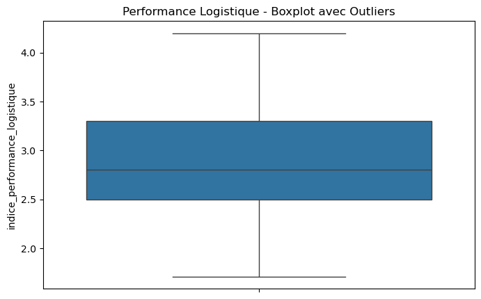

```
Outliers détectés : 0
Empty DataFrame
Columns: [pays, indice_performance_logistique]
Index: []
```

```python
# Boxplot avec outliers
plt.figure(figsize=(8, 5))
sns.boxplot(y=performance_logistique['indice_performance_logistique'])
plt.title('Performance Logistique - Boxplot avec Outliers')
plt.show()

# Compter les outliers
data_reset = performance_logistique.reset_index(drop=True)

Q1 = data_reset['indice_performance_logistique'].quantile(0.25)
Q3 = data_reset['indice_performance_logistique'].quantile(0.75)
IQR = Q3 - Q1
outliers = data_reset[(data_reset['indice_performance_logistique'] < Q1 - 1.5*IQR) |
                       (data_reset['indice_performance_logistique'] > Q3 + 1.5*IQR)]

print(f"Outliers détectés : {len(outliers)}")
print(outliers[['pays', 'indice_performance_logistique']])
```

## 2.6 - Taux_droit_douane

```python
#Affichage de la table Taux_droit_douane
Taux_droit_douane.head()
```

|  | Country Name | Country Code | Indicator Name | Indicator Code | 1960 | 1961 | 1962 | 1963 | 1964 | 1965 | ... | 2015 | 2016 | 2017 | 2018 | 2019 | 2020 | 2021 | 2022 | 2023 | 2024 |
| --- | --- | --- | --- | --- | --- | --- | --- | --- | --- | --- | --- | --- | --- | --- | --- | --- | --- | --- | --- | --- | --- |
| 0 | Aruba | ABW | Taux des droits de douane, appliqués, moyenne ... | TM.TAX.MRCH.WM.AR.ZS | NaN | NaN | NaN | NaN | NaN | NaN | ... | 10.02 | 10.16 | 10.3 | 10.15 | 12.12 | NaN | 9.66 | NaN | NaN | NaN |
| 1 | NaN | AFE | Taux des droits de douane, appliqués, moyenne ... | TM.TAX.MRCH.WM.AR.ZS | NaN | NaN | NaN | NaN | NaN | NaN | ... | NaN | NaN | NaN | NaN | NaN | NaN | NaN | NaN | NaN | NaN |
| 2 | Afghanistan | AFG | Taux des droits de douane, appliqués, moyenne ... | TM.TAX.MRCH.WM.AR.ZS | NaN | NaN | NaN | NaN | NaN | NaN | ... | NaN | NaN | NaN | 5.63 | NaN | NaN | NaN | NaN | NaN | NaN |
| 3 | NaN | AFW | Taux des droits de douane, appliqués, moyenne ... | TM.TAX.MRCH.WM.AR.ZS | NaN | NaN | NaN | NaN | NaN | NaN | ... | NaN | NaN | NaN | NaN | NaN | NaN | NaN | NaN | NaN | NaN |
| 4 | Angola | AGO | Taux des droits de douane, appliqués, moyenne ... | TM.TAX.MRCH.WM.AR.ZS | NaN | NaN | NaN | NaN | NaN | NaN | ... | 9.38 | 9.38 | NaN | 7.68 | 6.52 | 9.23 | 11.33 | 8.85 | NaN | NaN |

5 rows × 69 columns

```python
# Suppression des colonnes "Unnamed" inutiles s’il y en a
Taux_droit_douane = Taux_droit_douane.loc[:, ~Taux_droit_douane.columns.str.contains('^Unnamed')]
```

```python
# Transformation du format
Taux_droit_douane = Taux_droit_douane.melt(
    id_vars=['Country Name', 'Country Code', 'Indicator Name', 'Indicator Code'],
    var_name='annee',
    value_name='%droit_douane'
)

# Renommage des colonnes
Taux_droit_douane.rename(columns={
    'Country Name': 'pays',
    'Indicator Name': 'indicateur'
}, inplace=True)

# Conversion des années en numérique et suppression des NaN
Taux_droit_douane['annee'] = pd.to_numeric(Taux_droit_douane['annee'], errors='coerce')
Taux_droit_douane = Taux_droit_douane.dropna(subset=['%droit_douane'])
```

```python
# Séparer les données de 2022 et des autres années
Taux_droit_douane = Taux_droit_douane[Taux_droit_douane['annee'] == 2022].copy()
douane_autres = Taux_droit_douane[Taux_droit_douane['annee'] != 2022].copy()

# Garder la donnée la plus proche par pays
douane_autres = douane_autres.sort_values(by=['pays', 'annee'], ascending=[True, False])
douane_proche = douane_autres.drop_duplicates(subset='pays', keep='first')

# Remplir les NaN de 2022 avec les valeurs de l’année proche
Taux_droit_douane = Taux_droit_douane.combine_first(douane_proche)

# Affichage
print(" Données 2022 complétées :")
Taux_droit_douane
```

```
 Données 2022 complétées :
```

|  | pays | Country Code | indicateur | Indicator Code | annee | %droit_douane |
| --- | --- | --- | --- | --- | --- | --- |
| 16496 | Angola | AGO | Taux des droits de douane, appliqués, moyenne ... | TM.TAX.MRCH.WM.AR.ZS | 2022 | 8.85 |
| 16497 | Albanie | ALB | Taux des droits de douane, appliqués, moyenne ... | TM.TAX.MRCH.WM.AR.ZS | 2022 | 0.26 |
| 16501 | Argentine | ARG | Taux des droits de douane, appliqués, moyenne ... | TM.TAX.MRCH.WM.AR.ZS | 2022 | 6.45 |
| 16505 | Australie | AUS | Taux des droits de douane, appliqués, moyenne ... | TM.TAX.MRCH.WM.AR.ZS | 2022 | 0.99 |
| 16506 | Autriche | AUT | Taux des droits de douane, appliqués, moyenne ... | TM.TAX.MRCH.WM.AR.ZS | 2022 | 1.33 |
| ... | ... | ... | ... | ... | ... | ... |
| 16746 | Venezuela | VEN | Taux des droits de douane, appliqués, moyenne ... | TM.TAX.MRCH.WM.AR.ZS | 2022 | 12.84 |
| 16749 | Viet Nam | VNM | Taux des droits de douane, appliqués, moyenne ... | TM.TAX.MRCH.WM.AR.ZS | 2022 | 1.07 |
| 16750 | Vanuatu | VUT | Taux des droits de douane, appliqués, moyenne ... | TM.TAX.MRCH.WM.AR.ZS | 2022 | 11.48 |
| 16755 | Afrique du Sud | ZAF | Taux des droits de douane, appliqués, moyenne ... | TM.TAX.MRCH.WM.AR.ZS | 2022 | 4.66 |
| 16756 | Zambie | ZMB | Taux des droits de douane, appliqués, moyenne ... | TM.TAX.MRCH.WM.AR.ZS | 2022 | 4.08 |

144 rows × 6 columns

```python
# Suppression des colonnes inutiles
Taux_droit_douane = Taux_droit_douane.drop(
    columns=['Country Code', 'Indicator Code', 'annee', 'indicateur']).reset_index(drop=True)
```

```python
Taux_droit_douane.isna().any()
```

```
pays             False
%droit_douane    False
dtype: bool
```

```python
#Conservation des pays avec des correspondances avec la table dispo_alimentaire
douane_2 = Taux_droit_douane.copy()
dispo_2 = dispo_alimentaire.copy()

# Identifier les pays communs aux deux fichiers
pays_communs = set(dispo_2["pays"].dropna()).intersection(set(douane_2["pays"].dropna()))

# Filtrer le fichier Taux_droit_douane sur les pays communs
Taux_droit_douane = douane_2[douane_2["pays"].isin(pays_communs)].reset_index(drop=True)

# Afficher le nombre de lignes conservées
print(f"Fichier Taux_droit_douane : {len(Taux_droit_douane)} lignes conservées pour {len(pays_communs)} pays.")
```

```
Fichier Taux_droit_douane : 119 lignes conservées pour 119 pays.
```

```python
Taux_droit_douane
```

|  | pays | %droit_douane |
| --- | --- | --- |
| 0 | Angola | 8.85 |
| 1 | Albanie | 0.26 |
| 2 | Argentine | 6.45 |
| 3 | Australie | 0.99 |
| 4 | Autriche | 1.33 |
| ... | ... | ... |
| 114 | Venezuela | 12.84 |
| 115 | Viet Nam | 1.07 |
| 116 | Vanuatu | 11.48 |
| 117 | Afrique du Sud | 4.66 |
| 118 | Zambie | 4.08 |

119 rows × 2 columns

## Les outliers

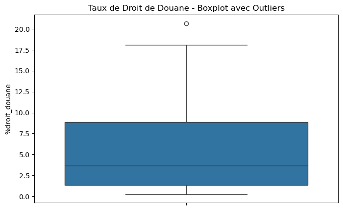

```
Outliers détectés : 1
            pays  %droit_douane
98  Îles Salomon          20.66
```

```python
# Boxplot avec outliers
plt.figure(figsize=(8, 5))
sns.boxplot(y=Taux_droit_douane['%droit_douane'])
plt.title('Taux de Droit de Douane - Boxplot avec Outliers')
plt.show()

# Compter les outliers
data_reset = Taux_droit_douane.reset_index(drop=True)

Q1 = data_reset['%droit_douane'].quantile(0.25)
Q3 = data_reset['%droit_douane'].quantile(0.75)
IQR = Q3 - Q1
outliers = data_reset[(data_reset['%droit_douane'] < Q1 - 1.5*IQR) |
                       (data_reset['%droit_douane'] > Q3 + 1.5*IQR)]

print(f"Outliers détectés : {len(outliers)}")
print(outliers[['pays', '%droit_douane']])
```

## Cet outlier vient du fait que les Îles Salomon appliquent un taux de droit de douane bien plus élevé que la moyenne des autres pays.

# Étape 3 - Jointure des fichiers

## 3.1 - Jointure

## Fusion de la table dispo_alimentaire et population

```python
# Fusion des deux tables uniquement sur 'pays'
dispo_alimentaire_hab = dispo_alimentaire.merge(population, on="pays", how="inner")
```

```python
# Conversion des unités : de milliers de tonnes en tonnes
dispo_alimentaire_hab["production_tonnes"] = dispo_alimentaire_hab["production"] * 1000
dispo_alimentaire_hab["importation_tonnes"] = dispo_alimentaire_hab["importation_qte"] * 1000
dispo_alimentaire_hab["disponibilite_interieure_tonnes"] = dispo_alimentaire_hab["disponibilite_interieure_qte"] * 1000

# Calcul par habitant (tonnes par personne) — en évitant la division par zéro
dispo_alimentaire_hab["production_par_habitant"] = dispo_alimentaire_hab["production_tonnes"] / dispo_alimentaire_hab["Population"].replace(0, np.nan)
dispo_alimentaire_hab["importation_par_habitant"] = dispo_alimentaire_hab["importation_tonnes"] / dispo_alimentaire_hab["Population"].replace(0, np.nan)
dispo_alimentaire_hab["disponibilite_interieure_par_habitant"] = dispo_alimentaire_hab["disponibilite_interieure_tonnes"] / dispo_alimentaire_hab["Population"].replace(0, np.nan)

# Conversion en kg par habitant
dispo_alimentaire_hab["production_kg_par_habitant"] = dispo_alimentaire_hab["production_par_habitant"] * 1000
dispo_alimentaire_hab["importation_kg_par_habitant"] = dispo_alimentaire_hab["importation_par_habitant"] * 1000
dispo_alimentaire_hab["disponibilite_interieure_kg_par_habitant"] = dispo_alimentaire_hab["disponibilite_interieure_par_habitant"] * 1000

#Changement du nom de la colonne Population en population
dispo_alimentaire_hab.rename(columns={"Population": "population"}, inplace=True)
# Affichage du résultat
dispo_alimentaire_hab.head()
```

|  | pays | produit | annee_x | production | importation_qte | disponibilite_interieure_qte | annee_y | population | production_tonnes | importation_tonnes | disponibilite_interieure_tonnes | production_par_habitant | importation_par_habitant | disponibilite_interieure_par_habitant | production_kg_par_habitant | importation_kg_par_habitant | disponibilite_interieure_kg_par_habitant |
| --- | --- | --- | --- | --- | --- | --- | --- | --- | --- | --- | --- | --- | --- | --- | --- | --- | --- |
| 0 | Afghanistan | Viande de Volailles | 2017 | 28.0 | 29.0 | 57.0 | 2018 | 37171000 | 28000.0 | 29000.0 | 57000.0 | 0.000753 | 0.000780 | 0.001533 | 0.753275 | 0.780178 | 1.533453 |
| 1 | Afrique du Sud | Viande de Volailles | 2017 | 1667.0 | 514.0 | 2118.0 | 2018 | 57792000 | 1667000.0 | 514000.0 | 2118000.0 | 0.028845 | 0.008894 | 0.036649 | 28.844823 | 8.893965 | 36.648671 |
| 2 | Albanie | Viande de Volailles | 2017 | 13.0 | 38.0 | 47.0 | 2018 | 2882000 | 13000.0 | 38000.0 | 47000.0 | 0.004511 | 0.013185 | 0.016308 | 4.510756 | 13.185288 | 16.308119 |
| 3 | Algérie | Viande de Volailles | 2017 | 275.0 | 2.0 | 277.0 | 2018 | 42228000 | 275000.0 | 2000.0 | 277000.0 | 0.006512 | 0.000047 | 0.006560 | 6.512267 | 0.047362 | 6.559629 |
| 4 | Allemagne | Viande de Volailles | 2017 | 1514.0 | 842.0 | 1739.0 | 2018 | 83124000 | 1514000.0 | 842000.0 | 1739000.0 | 0.018214 | 0.010129 | 0.020921 | 18.213753 | 10.129445 | 20.920552 |

```python
#Nombre de pays dans le fichier dispo_alimentaire_hab
dispo_alimentaire['pays'].nunique()
```

```
168
```

```python
colonnes_a_supprimer = [
    'produit',
    'annee_x',
    'production',
    'importation_qte',
    'disponibilite_interieure_qte',
    'annee_y',
    'production_tonnes',
    'importation_tonnes',
    'disponibilite_interieure_tonnes',
    'production_par_habitant',
    'importation_par_habitant',
    'disponibilite_interieure_par_habitant'
]

dispo_alimentaire_hab.drop(columns=colonnes_a_supprimer, inplace=True)

# Affichage du DataFrame nettoyé
dispo_alimentaire_hab.head()
```

|  | pays | population | production_kg_par_habitant | importation_kg_par_habitant | disponibilite_interieure_kg_par_habitant |
| --- | --- | --- | --- | --- | --- |
| 0 | Afghanistan | 37171000 | 0.753275 | 0.780178 | 1.533453 |
| 1 | Afrique du Sud | 57792000 | 28.844823 | 8.893965 | 36.648671 |
| 2 | Albanie | 2882000 | 4.510756 | 13.185288 | 16.308119 |
| 3 | Algérie | 42228000 | 6.512267 | 0.047362 | 6.559629 |
| 4 | Allemagne | 83124000 | 18.213753 | 10.129445 | 20.920552 |

## Fusion des tables dispo_alimentaire_hab et pib_hab

```python
dispo_alimentaire_pib = dispo_alimentaire_hab.merge(PIB_habitant, on="pays", how="inner")
dispo_alimentaire_pib
```

|  | pays | population | production_kg_par_habitant | importation_kg_par_habitant | disponibilite_interieure_kg_par_habitant | pib_hab |
| --- | --- | --- | --- | --- | --- | --- |
| 0 | Afghanistan | 37171000 | 0.753275 | 0.780178 | 1.533453 | 2122 |
| 1 | Afrique du Sud | 57792000 | 28.844823 | 8.893965 | 36.648671 | 14759 |
| 2 | Albanie | 2882000 | 4.510756 | 13.185288 | 16.308119 | 19446 |
| 3 | Algérie | 42228000 | 6.512267 | 0.047362 | 6.559629 | 15836 |
| 4 | Allemagne | 83124000 | 18.213753 | 10.129445 | 20.920552 | 67589 |
| ... | ... | ... | ... | ... | ... | ... |
| 141 | Zimbabwe | 14438000 | 4.779055 | 0.415570 | 5.263887 | 3560 |
| 142 | Émirats arabes unis | 9630000 | 4.984424 | 44.963655 | 42.782970 | 73777 |
| 143 | Équateur | 17084000 | 19.901662 | 0.000000 | 19.960197 | 15198 |
| 144 | Éthiopie | 109224000 | 0.128177 | 0.009155 | 0.128177 | 2844 |
| 145 | Îles Salomon | 652000 | 0.000000 | 9.202454 | 4.601227 | 2697 |

146 rows × 6 columns

## Fusion des tables dispo_alimentaire_pib et stabilite_politique

```python
donnees_1 = dispo_alimentaire_pib.merge(stabilite_politique, on="pays", how="inner")
donnees_1
```

|  | pays | population | production_kg_par_habitant | importation_kg_par_habitant | disponibilite_interieure_kg_par_habitant | pib_hab | stabilite |
| --- | --- | --- | --- | --- | --- | --- | --- |
| 0 | Afghanistan | 37171000 | 0.753275 | 0.780178 | 1.533453 | 2122 | -3 |
| 1 | Afrique du Sud | 57792000 | 28.844823 | 8.893965 | 36.648671 | 14759 | -1 |
| 2 | Albanie | 2882000 | 4.510756 | 13.185288 | 16.308119 | 19446 | 0 |
| 3 | Algérie | 42228000 | 6.512267 | 0.047362 | 6.559629 | 15836 | -1 |
| 4 | Allemagne | 83124000 | 18.213753 | 10.129445 | 20.920552 | 67589 | 1 |
| ... | ... | ... | ... | ... | ... | ... | ... |
| 141 | Zimbabwe | 14438000 | 4.779055 | 0.415570 | 5.263887 | 3560 | -1 |
| 142 | Émirats arabes unis | 9630000 | 4.984424 | 44.963655 | 42.782970 | 73777 | 1 |
| 143 | Équateur | 17084000 | 19.901662 | 0.000000 | 19.960197 | 15198 | 0 |
| 144 | Éthiopie | 109224000 | 0.128177 | 0.009155 | 0.128177 | 2844 | -2 |
| 145 | Îles Salomon | 652000 | 0.000000 | 9.202454 | 4.601227 | 2697 | 0 |

146 rows × 7 columns

## Fusion des tables donnees et performance_logistique

```python
donnees_2 = donnees_1.merge(performance_logistique, on="pays", how="inner")
donnees_2
```

|  | pays | population | production_kg_par_habitant | importation_kg_par_habitant | disponibilite_interieure_kg_par_habitant | pib_hab | stabilite | indice_performance_logistique |
| --- | --- | --- | --- | --- | --- | --- | --- | --- |
| 0 | Afghanistan | 37171000 | 0.753275 | 0.780178 | 1.533453 | 2122 | -3 | 1.900000 |
| 1 | Afrique du Sud | 57792000 | 28.844823 | 8.893965 | 36.648671 | 14759 | -1 | 3.700000 |
| 2 | Albanie | 2882000 | 4.510756 | 13.185288 | 16.308119 | 19446 | 0 | 2.500000 |
| 3 | Algérie | 42228000 | 6.512267 | 0.047362 | 6.559629 | 15836 | -1 | 2.500000 |
| 4 | Allemagne | 83124000 | 18.213753 | 10.129445 | 20.920552 | 67589 | 1 | 4.100000 |
| ... | ... | ... | ... | ... | ... | ... | ... | ... |
| 129 | Zimbabwe | 14438000 | 4.779055 | 0.415570 | 5.263887 | 3560 | -1 | 2.500000 |
| 130 | Émirats arabes unis | 9630000 | 4.984424 | 44.963655 | 42.782970 | 73777 | 1 | 4.000000 |
| 131 | Équateur | 17084000 | 19.901662 | 0.000000 | 19.960197 | 15198 | 0 | 2.880000 |
| 132 | Éthiopie | 109224000 | 0.128177 | 0.009155 | 0.128177 | 2844 | -2 | 2.376767 |
| 133 | Îles Salomon | 652000 | 0.000000 | 9.202454 | 4.601227 | 2697 | 0 | 2.800000 |

134 rows × 8 columns

## Fusion des tables donnees et imposition

```python
donnees_finale = donnees_2.merge(Taux_droit_douane, on="pays", how="inner")
donnees_finale
```

|  | pays | population | production_kg_par_habitant | importation_kg_par_habitant | disponibilite_interieure_kg_par_habitant | pib_hab | stabilite | indice_performance_logistique | %droit_douane |
| --- | --- | --- | --- | --- | --- | --- | --- | --- | --- |
| 0 | Afrique du Sud | 57792000 | 28.844823 | 8.893965 | 36.648671 | 14759 | -1 | 3.70 | 4.66 |
| 1 | Albanie | 2882000 | 4.510756 | 13.185288 | 16.308119 | 19446 | 0 | 2.50 | 0.26 |
| 2 | Algérie | 42228000 | 6.512267 | 0.047362 | 6.559629 | 15836 | -1 | 2.50 | 9.25 |
| 3 | Allemagne | 83124000 | 18.213753 | 10.129445 | 20.920552 | 67589 | 1 | 4.10 | 1.33 |
| 4 | Angola | 30809000 | 1.363238 | 8.990879 | 10.354117 | 7924 | -1 | 2.10 | 8.85 |
| ... | ... | ... | ... | ... | ... | ... | ... | ... | ... |
| 105 | Uruguay | 3449000 | 9.567991 | 0.869817 | 9.567991 | 33000 | 1 | 3.00 | 4.85 |
| 106 | Viet Nam | 95545000 | 9.608038 | 3.045685 | 12.622325 | 13905 | 0 | 3.30 | 1.07 |
| 107 | Zambie | 17351000 | 2.824045 | 0.691603 | 3.458014 | 3840 | 0 | 2.53 | 4.08 |
| 108 | Équateur | 17084000 | 19.901662 | 0.000000 | 19.960197 | 15198 | 0 | 2.88 | 5.19 |
| 109 | Îles Salomon | 652000 | 0.000000 | 9.202454 | 4.601227 | 2697 | 0 | 2.80 | 20.66 |

110 rows × 9 columns

```python
# Arrondir les colonnes
colonnes = [
    'production_kg_par_habitant',
    'importation_kg_par_habitant',
    'disponibilite_interieure_kg_par_habitant'
]

# Conversion en float et arrondi à 2 chiffres après la virgule
for col in colonnes:
    if col in donnees_finale.columns:
        donnees_finale[col] = donnees_finale[col].astype(float).round(2)
```

## 3.2 - Fichier final

## On obtient un fichier finale avec 110 pays contenant 8 variables

```python
# Liste de renommage
renommer_colonnes = {
    'pays': 'pays',
    'population': 'population',
    'production_kg_par_habitant': 'production_hab',
    'importation_kg_par_habitant': 'importation_hab',
    'disponibilite_interieure_kg_par_habitant': 'disponibilite_hab',
    'pib_hab': 'pib_hab',
    'stabilite': 'stabilite',
    'indice_performance_logistique': 'indice_perf_logistique',
    '%droit_douane': 'douane'
}

# Appliquer le renommage
donnees_finale = donnees_finale.rename(columns=renommer_colonnes)
```

```python
donnees_finale
```

|  | pays | population | production_hab | importation_hab | disponibilite_hab | pib_hab | stabilite | indice_perf_logistique | douane |
| --- | --- | --- | --- | --- | --- | --- | --- | --- | --- |
| 0 | Afrique du Sud | 57792000 | 28.84 | 8.89 | 36.65 | 14759 | -1 | 3.70 | 4.66 |
| 1 | Albanie | 2882000 | 4.51 | 13.19 | 16.31 | 19446 | 0 | 2.50 | 0.26 |
| 2 | Algérie | 42228000 | 6.51 | 0.05 | 6.56 | 15836 | -1 | 2.50 | 9.25 |
| 3 | Allemagne | 83124000 | 18.21 | 10.13 | 20.92 | 67589 | 1 | 4.10 | 1.33 |
| 4 | Angola | 30809000 | 1.36 | 8.99 | 10.35 | 7924 | -1 | 2.10 | 8.85 |
| ... | ... | ... | ... | ... | ... | ... | ... | ... | ... |
| 105 | Uruguay | 3449000 | 9.57 | 0.87 | 9.57 | 33000 | 1 | 3.00 | 4.85 |
| 106 | Viet Nam | 95545000 | 9.61 | 3.05 | 12.62 | 13905 | 0 | 3.30 | 1.07 |
| 107 | Zambie | 17351000 | 2.82 | 0.69 | 3.46 | 3840 | 0 | 2.53 | 4.08 |
| 108 | Équateur | 17084000 | 19.90 | 0.00 | 19.96 | 15198 | 0 | 2.88 | 5.19 |
| 109 | Îles Salomon | 652000 | 0.00 | 9.20 | 4.60 | 2697 | 0 | 2.80 | 20.66 |

110 rows × 9 columns

## 3.3 - Export du fichier final

```python
# Exporter donnees_finale en CSV
donnees_finale.to_csv('donnees_finale.csv', index=False, encoding='utf-8')
```